# Learning R

Rob Hayward

Thursday, August 28, 2014

# Further notes on dplyr

This comes from [HOXO-M](http://mockquant.blogspot.co.uk/2015/07/the-complete-catalog-of-argument.html)

```r
library(dplyr)
library(nycflights13)
set.seed(123)
data <- sample_n(flights, 3)
glimpse(data)
```

```
## Observations: 3
## Variables:
## $ year      (int) 2013, 2013, 2013
## $ month     (int) 12, 7, 3
## $ day       (int) 15, 17, 2
## $ dep_time  (int) 2124, 651, 1636
## $ dep_delay (dbl) -4, -9, 1
## $ arr_time  (int) 2322, 936, 1800
## $ arr_delay (dbl) 1, -28, 0
## $ carrier   (chr) "UA", "DL", "WN"
## $ tailnum   (chr) "N801UA", "N194DN", "N475WN"
## $ flight    (int) 289, 763, 1501
## $ origin    (chr) "EWR", "JFK", "LGA"
## $ dest      (chr) "DTW", "LAX", "MKE"
## $ air_time  (dbl) 88, 306, 103
## $ distance  (dbl) 488, 2475, 738
## $ hour      (dbl) 21, 6, 16
## $ minute    (dbl) 24, 51, 36
```

# Some notes on the dplyr package.

This comes from [Roger Penn}(https://www.youtube.com/watch?v=aywFompr1F4&list=TLmZovpghOuEo)

# Simple Simulation

# The apply family

This comes from [Rolling your Rs](http://rollingyours.wordpress.com/2014/05/15/the-apply-command-101/). `apply` is applied to a matrix or dataframe. It returns a matrix or vector. To take the mean of a column

```r
set.seed(1)
mymat <- matrix(round(rnorm(16, 10), 2), 4, 4)
apply(mymat, 2, mean)
```

```
## [1] 10.0775 10.1850 10.5425  9.5625
```

The number 2 indicates that it is run across columns. It would be 1 for rows. Addditional arguments can be passed to the function. For example, `na.rm` or `trim`.

```r
apply(mymat, 2, mean, na.rm = T, trim = 0.5)
```

```
## [1]  9.775 10.410 10.485  9.670
```

Functions can also be passed anonymously.

```r
apply(mymat, 2, function(x) x/sum(x))
```

```
##           [,1]      [,2]      [,3]      [,4]
## [1,] 0.2324485 0.2535592 0.2508893 0.2452288
## [2,] 0.2525428 0.2253314 0.2297842 0.2036601
## [3,] 0.2272389 0.2574865 0.2729429 0.2907190
## [4,] 0.2877698 0.2636230 0.2463837 0.2603922
```

Final example,

```r
url <- "http://steviep42.bitbucket.org/data/su_et_al_2002.txt"
mydata <- read.csv(url, header = T)
str(mydata)
```

```
## 'data.frame':    12626 obs. of  8 variables:
##  $ B1 : num  9.37 11.57 7.79 6.56 7.26 ...
##  $ B2 : num  9.5 11.51 6.69 7.45 7.39 ...
##  $ FB1: num  7.89 10.56 7.91 5.93 8.75 ...
##  $ FB2: num  7.96 10.34 7.57 7.53 8.19 ...
##  $ FL1: num  7.7 10.26 8.25 7.84 9.45 ...
##  $ FL2: num  8.1 10.13 8.53 8.16 8.19 ...
##  $ L1 : num  9.22 10.23 8.39 11.02 9.19 ...
##  $ L2 : num  8.9 10.49 8.47 11.09 9.42 ...
```

```r
apply(mydata, 2, function(x) c(mu = mean(x), sd = sd(x)))
```

```
##          B1       B2      FB1      FB2      FL1      FL2       L1       L2
## mu 7.615090 7.431602 7.879343 7.770545 7.730293 7.601395 7.415937 7.518259
## sd 2.257218 2.452364 2.150741 2.254736 2.207076 2.355612 2.405326 2.365394
```

# lapply command 101

This comes from [Rolling your Rs](http://rollingyours.wordpress.com/2014/10/20/the-lapply-command-101/) This is a very important way of dealing with lists. This is the way to hold hetrogenous data. Create a list for family attributed.

```r
family1 <- list(name = "Jones", numofchild = 2, ages = c(5, 7),
                measles = c("Y", "N"))
```

The `lapply` function can be applied to this list. The following loops through the list to find the class of each element.

```r
str(lapply(family1, typeof))
```

```
## List of 4
##  $ name      : chr "character"
##  $ numofchild: chr "double"
##  $ ages      : chr "double"
##  $ measles   : chr "character"
```

To show how to pass an anonymous function to `lapply`,

```r
str(lapply(family1, function(x) typeof(x)))
```

```
## List of 4
##  $ name      : chr "character"
##  $ numofchild: chr "double"
##  $ ages      : chr "double"
##  $ measles   : chr "character"
```

The function can also be defined in advance.

```r
simplefunc <- function(x){
  mytype <- typeof(x)
  return(mytype)
}
lapply(family1, simplefunc)
```

```
## $name
## [1] "character"
##
## $numofchild
## [1] "double"
##
## $ages
## [1] "double"
##
## $measles
## [1] "character"
```

It is possible to create a list of families

```r
family2 <- list(name="Espinoza",numofchild=4,ages=c(5,7,9,11),measles=c("Y","N","Y","Y"))
family3 <- list(name="Ginsberg",numofchild=3,ages=c(9,13,18),measles=c("Y","N","Y"))
family4 <- list(name="Souza",numofchild=5,ages=c(3,5,7,9,11),measles=c("N","Y","Y","Y","N"))
allfams <- list(f1=family1,f2=family2,f3=family3,f4=family4)
lapply(allfams, function(x) mean(x$ages))
```

```
## $f1
## [1] 6
##
## $f2
## [1] 8
##
## $f3
## [1] 13.33333
##
## $f4
## [1] 7
```

The `lapply` function can be used effectivley with the `split` function. `split` will return a list of dataframes. For example, it is possible to split the mcars dataframe into cylinder types.

```r
unique(mtcars$cyl)
```

```
## [1] 6 4 8
```

```r
mydfs <- split(mtcars, mtcars$cyl)
str(mydfs, max.level = 1)
```

```
## List of 3
##  $ 4:'data.frame':   11 obs. of  11 variables:
##  $ 6:'data.frame':   7 obs. of  11 variables:
##  $ 8:'data.frame':   14 obs. of  11 variables:
```

```r
lapply(mydfs, function(x) mean(x$mpg))
```

```
## $`4`
## [1] 26.66364
##
## $`6`
## [1] 19.74286
##
## $`8`
## [1] 15.1
```

Or more advanced

```r
tapply(mtcars$mpg, mtcars$cyl, mean)
```

```
##        4        6        8
## 26.66364 19.74286 15.10000
```

# Tidy and dplyr from HW

This comes from [R-Studio video.](http://pages.rstudio.net/Webinar-Series-Recording-Essential-Tools-for-R.html?mkt_tok=3RkMMJWWfF9wsRonuqzMZKXonjHpfsX56uovXKO2lMI%2F0ER3fOvrPUfGjI4ATMFlI%2BSLDwEYGJlv6SgFTbDMMa541LgKWxc%3D) Not sure how long this will last. The first part is about the package `tidyr`. The three main commands are **gather**, **spread** and **separate**. There is a 30-page document about *tidy data*. There can be a link between `tidyr` and `dplyr` and `ggvis`.

The process of data analysis has three stages: think it, describe it and do it. The commands for dplyr

- filter: keep rows matching criteria
- select: pick columns by name
- arrange: reorder rows
- mutate: add new vaiables
- summarise: reduce varibles to vaules

This reduceds the **thinking** part of the data analysis.

For the presentation of data use `ggvis`. This can flow from *The Grammer of Graphics*. There are links between `ggplot2` and `ggvis`. All the data are available in [github.](https://github.com/rstudio/webinars)  
#’dplyr intro from Rstudio This comes from [R-Studio.](http://blog.rstudio.org/2014/01/17/introducing-dplyr/). The aim is to draw the list of baseball players with the most games.

```r
library(Lahman)
library(dplyr)
players <- group_by(Batting, playerID)
games <- summarise(players, total = sum(G))
head(arrange(games, desc(total)), 5)
```

```
## Source: local data frame [5 x 2]
##
##    playerID total
## 1  rosepe01  3562
## 2 yastrca01  3308
## 3 aaronha01  3298
## 4 henderi01  3081
## 5  cobbty01  3035
```

Operations can be chained together with the `%.%` operator. For example,

```r
Batting %.%
  group_by(playerID) %.%
  summarise(total = sum(G)) %.%
  arrange(desc(total))%.%
  head(5)
```

```
## Source: local data frame [5 x 2]
##
##    playerID total
## 1  rosepe01  3562
## 2 yastrca01  3308
## 3 aaronha01  3298
## 4 henderi01  3081
## 5  cobbty01  3035
```

From the introductory vignette that can be accessed by `vignette("introduction", package = "dplyr")`

## Video overview

This is the video from [R-videos](http://practicalrvideos.blogspot.co.uk/2014/08/dplyr-gamechanger-for-data-manipulation.html)

Load the Titanic data.

```r
library(ggplot2)
train = read.csv("../../Data/train.csv")
head(train)
```

```
##   PassengerId Survived Pclass
## 1           1        0      3
## 2           2        1      1
## 3           3        1      3
## 4           4        1      1
## 5           5        0      3
## 6           6        0      3
##                                                  Name    Sex Age SibSp
## 1                             Braund, Mr. Owen Harris   male  22     1
## 2 Cumings, Mrs. John Bradley (Florence Briggs Thayer) female  38     1
## 3                              Heikkinen, Miss. Laina female  26     0
## 4        Futrelle, Mrs. Jacques Heath (Lily May Peel) female  35     1
## 5                            Allen, Mr. William Henry   male  35     0
## 6                                    Moran, Mr. James   male  NA     0
##   Parch           Ticket    Fare Cabin Embarked
## 1     0        A/5 21171  7.2500              S
## 2     0         PC 17599 71.2833   C85        C
## 3     0 STON/O2. 3101282  7.9250              S
## 4     0           113803 53.1000  C123        S
## 5     0           373450  8.0500              S
## 6     0           330877  8.4583              Q
```

key functions in dplyr

- *select:* select columns from a dataframe
- *filter:* select rows from a data frame based upon criteria
- *group_by:* group by a factor variable
- *summarize:* allows you to do summary stats based upon the grouped variable
- *arrange:* a better way to order the data set

### Selecting columns and rows of a dataframe

Selecting columns

```r
VariablesThatICareAbout = select(train, Survived, Pclass, Sex, Age, SibSp, Parch, Fare)
head(VariablesThatICareAbout)
```

```
##   Survived Pclass    Sex Age SibSp Parch    Fare
## 1        0      3   male  22     1     0  7.2500
## 2        1      1 female  38     1     0 71.2833
## 3        1      3 female  26     0     0  7.9250
## 4        1      1 female  35     1     0 53.1000
## 5        0      3   male  35     0     0  8.0500
## 6        0      3   male  NA     0     0  8.4583
```

Everything except for PassengerId:

```r
VariablesThatICareAbout = select(train, -PassengerId)
head(VariablesThatICareAbout)
```

```
##   Survived Pclass                                                Name
## 1        0      3                             Braund, Mr. Owen Harris
## 2        1      1 Cumings, Mrs. John Bradley (Florence Briggs Thayer)
## 3        1      3                              Heikkinen, Miss. Laina
## 4        1      1        Futrelle, Mrs. Jacques Heath (Lily May Peel)
## 5        0      3                            Allen, Mr. William Henry
## 6        0      3                                    Moran, Mr. James
##      Sex Age SibSp Parch           Ticket    Fare Cabin Embarked
## 1   male  22     1     0        A/5 21171  7.2500              S
## 2 female  38     1     0         PC 17599 71.2833   C85        C
## 3 female  26     0     0 STON/O2. 3101282  7.9250              S
## 4 female  35     1     0           113803 53.1000  C123        S
## 5   male  35     0     0           373450  8.0500              S
## 6   male  NA     0     0           330877  8.4583              Q
```

Columns Survived to Age

```r
VariablesThatICareAbout = select(train, Survived:Age)
head(VariablesThatICareAbout)
```

```
##   Survived Pclass                                                Name
## 1        0      3                             Braund, Mr. Owen Harris
## 2        1      1 Cumings, Mrs. John Bradley (Florence Briggs Thayer)
## 3        1      3                              Heikkinen, Miss. Laina
## 4        1      1        Futrelle, Mrs. Jacques Heath (Lily May Peel)
## 5        0      3                            Allen, Mr. William Henry
## 6        0      3                                    Moran, Mr. James
##      Sex Age
## 1   male  22
## 2 female  38
## 3 female  26
## 4 female  35
## 5   male  35
## 6   male  NA
```

Selecting rows: only first class passengers

```r
FirstClass = filter(train, Pclass == 1)
head(FirstClass)
```

```
##   PassengerId Survived Pclass
## 1           2        1      1
## 2           4        1      1
## 3           7        0      1
## 4          12        1      1
## 5          24        1      1
## 6          28        0      1
##                                                  Name    Sex Age SibSp
## 1 Cumings, Mrs. John Bradley (Florence Briggs Thayer) female  38     1
## 2        Futrelle, Mrs. Jacques Heath (Lily May Peel) female  35     1
## 3                             McCarthy, Mr. Timothy J   male  54     0
## 4                            Bonnell, Miss. Elizabeth female  58     0
## 5                        Sloper, Mr. William Thompson   male  28     0
## 6                      Fortune, Mr. Charles Alexander   male  19     3
##   Parch   Ticket     Fare       Cabin Embarked
## 1     0 PC 17599  71.2833         C85        C
## 2     0   113803  53.1000        C123        S
## 3     0    17463  51.8625         E46        S
## 4     0   113783  26.5500        C103        S
## 5     0   113788  35.5000          A6        S
## 6     2    19950 263.0000 C23 C25 C27        S
```

Only first class male passengers

```r
FirstClass = filter(train, Pclass == 1 & Sex == "male")
head(FirstClass)
```

```
##   PassengerId Survived Pclass                           Name  Sex Age
## 1           7        0      1        McCarthy, Mr. Timothy J male  54
## 2          24        1      1   Sloper, Mr. William Thompson male  28
## 3          28        0      1 Fortune, Mr. Charles Alexander male  19
## 4          31        0      1       Uruchurtu, Don. Manuel E male  40
## 5          35        0      1        Meyer, Mr. Edgar Joseph male  28
## 6          36        0      1 Holverson, Mr. Alexander Oskar male  42
##   SibSp Parch   Ticket     Fare       Cabin Embarked
## 1     0     0    17463  51.8625         E46        S
## 2     0     0   113788  35.5000          A6        S
## 3     3     2    19950 263.0000 C23 C25 C27        S
## 4     0     0 PC 17601  27.7208                    C
## 5     1     0 PC 17604  82.1708                    C
## 6     1     0   113789  52.0000                    S
```

Ordering the rows by fare and then class. To switch round the put `-Fare`

```r
train = arrange(train, Fare, Pclass)
head(train)
```

```
##   PassengerId Survived Pclass                            Name  Sex Age
## 1         264        0      1           Harrison, Mr. William male  40
## 2         634        0      1   Parr, Mr. William Henry Marsh male  NA
## 3         807        0      1          Andrews, Mr. Thomas Jr male  39
## 4         816        0      1                Fry, Mr. Richard male  NA
## 5         823        0      1 Reuchlin, Jonkheer. John George male  38
## 6         278        0      2     Parkes, Mr. Francis "Frank" male  NA
##   SibSp Parch Ticket Fare Cabin Embarked
## 1     0     0 112059    0   B94        S
## 2     0     0 112052    0              S
## 3     0     0 112050    0   A36        S
## 4     0     0 112058    0  B102        S
## 5     0     0  19972    0              S
## 6     0     0 239853    0              S
```

### Multiple commands in a single step

The main value is the ability to pipe the output from one command into another use `%>%` to pipe one command into another. This means that the `select` statement will be piped into the `group-by` statement and that will be piped into the `summarize` statement.

Average fare by passenger class

```r
select(train, Pclass, Fare, Survived) %>%
  group_by(Pclass) %>% #don't have to specify the dataset a second time
  summarize(AvgFare = mean(Fare), ProbSurvived = mean(Survived), N = length(Fare))
```

```
## Source: local data frame [3 x 4]
##
##   Pclass  AvgFare ProbSurvived   N
## 1      1 84.15469    0.6296296 216
## 2      2 20.66218    0.4728261 184
## 3      3 13.67555    0.2423625 491
```

Just change the `group-by` statement to look at the survival by sex.

```r
select(train, Sex, Survived) %>%
  group_by(Sex) %>%
  summarize(ProbSurvived = mean(Survived))
```

```
## Source: local data frame [2 x 2]
##
##      Sex ProbSurvived
## 1 female    0.7420382
## 2   male    0.1889081
```

Both categories at the same time! (group by two variables)

```r
A = select(train, Pclass, Sex, Fare, Survived) %>%
  group_by(Pclass, Sex) %>% #don't have to specify the dataset a second time
  summarize(AvgFare = mean(Fare), ProbSurvived = mean(Survived), N = length(Fare))
A
```

```
## Source: local data frame [6 x 5]
## Groups: Pclass
##
##   Pclass    Sex   AvgFare ProbSurvived   N
## 1      1 female 106.12580    0.9680851  94
## 2      1   male  67.22613    0.3688525 122
## 3      2 female  21.97012    0.9210526  76
## 4      2   male  19.74178    0.1574074 108
## 5      3 female  16.11881    0.5000000 144
## 6      3   male  12.66163    0.1354467 347
```

Variable creation Use the mutate function

```r
train = mutate(train
               , AgeByFare = Age * Fare
               , Age2 = Age^2)
#allows you to create variables in one step
#without specifying the data frame a bunch of times
train$Age2 = train$Age^2
```

### ggplot teaser There will be another tutorial on ggplot Just wanted to show this to motivate using ggplot! dplyr makes it easier to produce grouped plots in ggplot

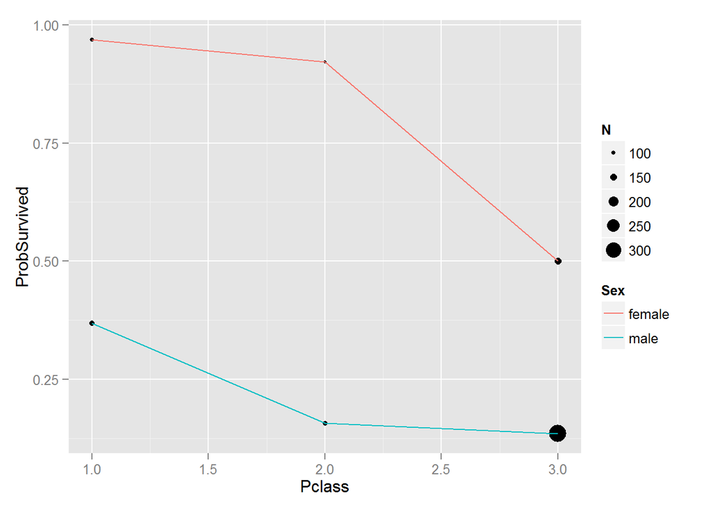

```r
ggplot(A, aes(x = Pclass, y = ProbSurvived)) +
  geom_point(aes(size = N)) +
  geom_line(aes(by = Sex, color = Sex))
```

Survival probability unaffected for male 2 or 3 class, but big difference for females in 2nd and 3rd class